# Titanic Analysis Python

**MY WEBSITE**

Who would have died on **the Titanic** ?

**Summary**  
**I** - Data cleaning and First intuitions  
**A** - First taking of information  
**B** - Intuitive prediction  
**II** - Machine Learning Algorithms  
**A** - Random Forest  
**a**. Importance of variables  
**b**. Prediction Score  
**B** - Decision Tree

**PART I: DATA CLEANING AND FIRST INTUITIONS**

**I. A - First Taking of Informations - Data Cleaning**

We will initially associate our data with a dataframe and give ourselves means to have a first vision of this set.

```python
import pandas as pd
import numpy as np

titanic_df = pd.read_csv("data/train_titanic.csv", sep=';')
print(titanic_df.dtypes)
titanic_df.head(5)
```

```
PassengerId      int64
Survived        object
Pclass           int64
Name            object
Sex             object
Age            float64
SibSp            int64
Parch            int64
Ticket          object
Fare           float64
Cabin           object
Embarked        object
dtype: object
```

|  | PassengerId | Survived | Pclass | Name | Sex | Age | SibSp | Parch | Ticket | Fare | Cabin | Embarked |
| --- | --- | --- | --- | --- | --- | --- | --- | --- | --- | --- | --- | --- |
| 0 | 503 | No | 3 | O'Sullivan, Miss. Bridget Mary | female | NaN | 0 | 0 | 330909 | 7.6292 | NaN | Q |
| 1 | 504 | No | 3 | Laitinen, Miss. Kristina Sofia | female | 37.0 | 0 | 0 | 4135 | 9.5875 | NaN | S |
| 2 | 511 | Yes | 3 | Daly, Mr. Eugene Patrick | male | 29.0 | 0 | 0 | 382651 | 7.7500 | NaN | Q |
| 3 | 521 | Yes | 1 | Perreault, Miss. Anne | female | 30.0 | 0 | 0 | 12749 | 93.5000 | B73 | S |
| 4 | 530 | No | 2 | Hocking, Mr. Richard George | male | 23.0 | 2 | 1 | 29104 | 11.5000 | NaN | S |

We can also create a new column from an older.  
In fact in the column "Name" there is 3 information (Lastname, Title. Firstname) separated by ',' and '.'.  
Using the same separator '|', we can easily create a new column "Title" from the column name spliting information according to the separator.

```python
titanic_df['Name'] = titanic_df['Name'].str.replace(',', '|')
titanic_df['Name'] = titanic_df['Name'].str.replace('.', '|')
titanic_df = titanic_df.join(titanic_df['Name'].apply(lambda x: pd.Series(x.split('|'))))

titanic_df['Firstname'] = titanic_df[0]
titanic_df['Title'] = titanic_df[1]
titanic_df['Lastname'] = titanic_df[2]
del titanic_df['Name']
del titanic_df[0]
del titanic_df[1]
del titanic_df[2]
del titanic_df[3]
titanic_df.head()
```

|  | PassengerId | Survived | Pclass | Sex | Age | SibSp | Parch | Ticket | Fare | Cabin | Embarked | Firstname | Title | Lastname |
| --- | --- | --- | --- | --- | --- | --- | --- | --- | --- | --- | --- | --- | --- | --- |
| 0 | 503 | No | 3 | female | NaN | 0 | 0 | 330909 | 7.6292 | NaN | Q | O'Sullivan | Miss | Bridget Mary |
| 1 | 504 | No | 3 | female | 37.0 | 0 | 0 | 4135 | 9.5875 | NaN | S | Laitinen | Miss | Kristina Sofia |
| 2 | 511 | Yes | 3 | male | 29.0 | 0 | 0 | 382651 | 7.7500 | NaN | Q | Daly | Mr | Eugene Patrick |
| 3 | 521 | Yes | 1 | female | 30.0 | 0 | 0 | 12749 | 93.5000 | B73 | S | Perreault | Miss | Anne |
| 4 | 530 | No | 2 | male | 23.0 | 2 | 1 | 29104 | 11.5000 | NaN | S | Hocking | Mr | Richard George |

We reorganize our dataframe for the first time, taking care to keep only the interesting columns. And we look at whether our numerical columns have missing values:

```python
print("Valeurs manquantes")
print("Age:", pd.isnull(titanic_df.Age).values.any())
print("Fare:", pd.isnull(titanic_df.Fare).values.any())
print("Pclass:", pd.isnull(titanic_df.Pclass).values.any())
titanic_df = titanic_df[['Title', 'Firstname', 'Lastname','Sex', 'Age', 'Pclass', 'Fare', 'Embarked', 'Survived']]
titanic_df.head(5)
```

```
Valeurs manquantes
Age: True
Fare: False
Pclass: False
```

|  | Title | Firstname | Lastname | Sex | Age | Pclass | Fare | Embarked | Survived |
| --- | --- | --- | --- | --- | --- | --- | --- | --- | --- |
| 0 | Miss | O'Sullivan | Bridget Mary | female | NaN | 3 | 7.6292 | Q | No |
| 1 | Miss | Laitinen | Kristina Sofia | female | 37.0 | 3 | 9.5875 | S | No |
| 2 | Mr | Daly | Eugene Patrick | male | 29.0 | 3 | 7.7500 | Q | Yes |
| 3 | Miss | Perreault | Anne | female | 30.0 | 1 | 93.5000 | S | Yes |
| 4 | Mr | Hocking | Richard George | male | 23.0 | 2 | 11.5000 | S | No |

We note that the Age column has missing values that will be replaced by the median age of all passengers.  
We can now call the describe function

```python
median_age = titanic_df['Age'].dropna().median()
if len(titanic_df.Age[ titanic_df.Age.isnull() ]) > 0:
    titanic_df.loc[(titanic_df.Age.isnull()), 'Age'] = median_age

titanic_df.describe()
```

|  | Age | Pclass | Fare |
| --- | --- | --- | --- |
| count | 891.000000 | 891.000000 | 891.000000 |
| mean | 29.361582 | 2.308642 | 32.204208 |
| std | 13.019697 | 0.836071 | 49.693429 |
| min | 0.420000 | 1.000000 | 0.000000 |
| 25% | 22.000000 | 2.000000 | 7.910400 |
| 50% | 28.000000 | 3.000000 | 14.454200 |
| 75% | 35.000000 | 3.000000 | 31.000000 |
| max | 80.000000 | 3.000000 | 512.329200 |

Let's look at the Title column. We would like to display the different titles present on the boat.

```python
titanic_df['Title'].value_counts()
```

```
 Mr              517
 Miss            182
 Mrs             125
 Master           40
 Dr                7
 Rev               6
 Mlle              2
 Major             2
 Col               2
 Sir               1
 Ms                1
 Jonkheer          1
 the Countess      1
 Don               1
 Mme               1
 Lady              1
 Capt              1
Name: Title, dtype: int64
```

Finally we can summaryze our data defining the shape of our dataframe.

```python
print("Dataframe (ligne(s), colonne(s)) = ", titanic_df.shape)
```

```
Dataframe (ligne(s), colonne(s)) =  (891, 9)
```

**I. B - Intuitive Prediction**

Now that we have been able to clean / observe our dataframe we will be able to begin the study of this one by first looking at how many survivors there were for how many deaths and then proportions of these numbers.

```python
print("Nombre:\n", titanic_df.Survived.value_counts())
print("\nProportions:\n", titanic_df.Survived.value_counts("Proportion"))
```

```
Nombre:
 No     549
Yes    342
Name: Survived, dtype: int64

Proportions:
 No     0.616162
Yes    0.383838
Name: Survived, dtype: float64
```

Now we will replace values of the Survived column  
Yes -> 1  
No -> 0

```python
titanic_df.Survived = titanic_df.Survived.map(dict(Yes=1, No=0))
titanic_df.head(5)
```

|  | Title | Firstname | Lastname | Sex | Age | Pclass | Fare | Embarked | Survived |
| --- | --- | --- | --- | --- | --- | --- | --- | --- | --- |
| 0 | Miss | O'Sullivan | Bridget Mary | female | 28.0 | 3 | 7.6292 | Q | 0 |
| 1 | Miss | Laitinen | Kristina Sofia | female | 37.0 | 3 | 9.5875 | S | 0 |
| 2 | Mr | Daly | Eugene Patrick | male | 29.0 | 3 | 7.7500 | Q | 1 |
| 3 | Miss | Perreault | Anne | female | 30.0 | 1 | 93.5000 | S | 1 |
| 4 | Mr | Hocking | Richard George | male | 23.0 | 2 | 11.5000 | S | 0 |

So we can see that only 38% of passengers have survived.  
We will create a new column 'Survived_Hypo' considering initially that all the passengers are dead.  
It is this column that will be modified gradually to create our model of prediction.  
Logically, our model will then be just at 62%.

```python
titanic_df['Survived_Hypo'] = 0
titanic_df.head(5)
```

|  | Title | Firstname | Lastname | Sex | Age | Pclass | Fare | Embarked | Survived | Survived_Hypo |
| --- | --- | --- | --- | --- | --- | --- | --- | --- | --- | --- |
| 0 | Miss | O'Sullivan | Bridget Mary | female | 28.0 | 3 | 7.6292 | Q | 0 | 0 |
| 1 | Miss | Laitinen | Kristina Sofia | female | 37.0 | 3 | 9.5875 | S | 0 | 0 |
| 2 | Mr | Daly | Eugene Patrick | male | 29.0 | 3 | 7.7500 | Q | 1 | 0 |
| 3 | Miss | Perreault | Anne | female | 30.0 | 1 | 93.5000 | S | 1 | 0 |
| 4 | Mr | Hocking | Richard George | male | 23.0 | 2 | 11.5000 | S | 0 | 0 |

We can create a function that will determine (using a temp column) how close our model is to the reality.

```python
def comparaison_modele_realite(df):
  df['Comp'] = np.where(df['Survived'] == df['Survived_Hypo'], 1, 0)
  print (round(df['Comp'].sum()*100/len(df)),"% close to the reality")
  del df['Comp']

comparaison_modele_realite(titanic_df)
```

```
62.0 % close to the reality
```

We find well 62%.  
Now we can work on a new mortality factor such as sex

```python
titanic_df.groupby('Sex').sum()
```

| Sex | Age | Pclass | Fare | Survived | Survived_Hypo |
| --- | --- | --- | --- | --- | --- |
| female | 8770.00 | 678 | 13966.6628 | 233 | 0 |
| male | 17391.17 | 1379 | 14727.2865 | 109 | 0 |

We note that many more women survived "Women and children first!".  
So we have to change our 'Survived_Hypo' column and make sure all women survived.  
To summarize, all men die and women are still alive.

```python
titanic_df['Survived_Hypo'] = np.where(titanic_df['Sex'] == "female", 1, 0)
titanic_df.head(5)
```

|  | Title | Firstname | Lastname | Sex | Age | Pclass | Fare | Embarked | Survived | Survived_Hypo |
| --- | --- | --- | --- | --- | --- | --- | --- | --- | --- | --- |
| 0 | Miss | O'Sullivan | Bridget Mary | female | 28.0 | 3 | 7.6292 | Q | 0 | 1 |
| 1 | Miss | Laitinen | Kristina Sofia | female | 37.0 | 3 | 9.5875 | S | 0 | 1 |
| 2 | Mr | Daly | Eugene Patrick | male | 29.0 | 3 | 7.7500 | Q | 1 | 0 |
| 3 | Miss | Perreault | Anne | female | 30.0 | 1 | 93.5000 | S | 1 | 1 |
| 4 | Mr | Hocking | Richard George | male | 23.0 | 2 | 11.5000 | S | 0 | 0 |

Another way to calculate the link between two columns is to use the method accuracy_score from 'sklearn.metrics' library.

```python
from sklearn.metrics import accuracy_score

accuracy_score(titanic_df.Survived, titanic_df.Survived_Hypo)
```

```
0.78675645342312006
```

After that, our model is even closer to reality 62 -> 79  
Unfortunately not all women survived. We will therefore look for a criterion that could divide the women, such as age or wealth (the cost of the ticket / class in the boat).  
Let's say that 25% of the women who bought the cheapest tickets died.

```python
titanic_df.Survived_Hypo = 0
titanic_df.loc[(titanic_df.Sex == "female"), "Survived_Hypo"] = 1

quart_age = int((titanic_df.Fare.quantile([.25])))
titanic_df.loc[(titanic_df.Sex == "female")
               & (titanic_df.Fare <= quart_age)
               & (titanic_df.Pclass == 3), "Survived_Hypo"] = 0

accuracy_score(titanic_df.Survived, titanic_df.Survived_Hypo)
```

```
0.78787878787878785
```

**PART II:** MACHINE LEARNING ALGORITHMS

**II. A. a - Random Forest: *Importance of variables***

We will realize a new prediction by recovering the most important variables in the decision of survival of the passengers.  
Firstly the idea is to import all the libraries needed for our work.  
Then we must know that we can only work with numerical values, so we will replace men by 1 and women by 0 and thene Title by numbers from 0 to 16.

```python
from pandas import Series, DataFrame
import matplotlib.pylab as plt
import sklearn.metrics
from sklearn import preprocessing

# Initialize label encoder
label_encoder = preprocessing.LabelEncoder()
# Convert some variables to numeric
titanic_df["Sex"] = label_encoder.fit_transform(titanic_df["Sex"])
titanic_df["Title"] = label_encoder.fit_transform(titanic_df["Title"])
titanic_df.head(3)
```

|  | Title | Firstname | Lastname | Sex | Age | Pclass | Fare | Embarked | Survived | Survived_Hypo |
| --- | --- | --- | --- | --- | --- | --- | --- | --- | --- | --- |
| 0 | 8 | O'Sullivan | Bridget Mary | 0 | 28.0 | 3 | 7.6292 | Q | 0 | 1 |
| 1 | 8 | Laitinen | Kristina Sofia | 0 | 37.0 | 3 | 9.5875 | S | 0 | 1 |
| 2 | 11 | Daly | Eugene Patrick | 1 | 29.0 | 3 | 7.7500 | Q | 1 | 0 |

We will select the set of variables that interest us:

```
1. Sex
2. Age
3. Ticket price
4. Class in the boat
```

From then we define only one target that will naturally be our Survived column.  
Then the idea is to make a prediction with 'predictors' on a random part of our data (.4 here -> 40% of 891 equal to 357) it's bootstrap principle.

```python
from sklearn.cross_validation import train_test_split

features = ['Age', 'Sex', 'Fare', 'Pclass']
predictors = titanic_df[features]
target = titanic_df.Survived
split = train_test_split(titanic_df, target, test_size=0.4, random_state=42)
data_train, data_test, target_train, target_test = split
print('full shape:', titanic_df.shape, '\ntest shape:', data_test.shape, '\ntrain shape:', data_train.shape)
```

```
full shape: (891, 10)
test shape: (357, 10)
train shape: (534, 10)
```

```
  1. Age -> 0.266334
  2. Sex -> 0.258859
  3. Fare -> 0.357780
  4. Pclass -> 0.117027
```

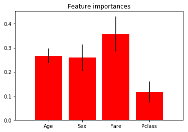

```python
import numpy as np
import matplotlib.pyplot as plt
from sklearn.ensemble import RandomForestClassifier as RandomForest

model = RandomForest(n_estimators=10)
model.fit(data_train[features], target_train)
importances = model.feature_importances_
std = np.std([tree.feature_importances_ for tree in model.estimators_], axis=0)

for feature, imp, i in zip(features, importances, range(len(features))):
    print("  %d. %s -> %f" % (i+1, feature, imp))

# Plot the feature importances of the forest
plt.figure()
plt.title("Feature importances")
plt.bar(range(len(features)), importances, color="r", yerr=std, align="center")
plt.xticks(range(len(features)), np.array(features))
plt.xlim([-1, len(features)])
plt.show()
```

**II. A. b - Random Forest: *Score Prediction***

The 'confusion matrix' is a square matrix whose diagonal (top left to bottom right) represents the number of values correctly predicted.  
In the same way, metrics.accuracy_score will calculate a prediction score.  
The set will never be equal from one compilation to the other due to the phenomenon of bootstrap which will in each case look for different data.

```python
from sklearn.metrics import confusion_matrix

prediction = model.predict(data_test[features])
print("Confusion matrix:\n", sklearn.metrics.confusion_matrix(target_test, prediction))
print("\nScore:\n", sklearn.metrics.accuracy_score(target_test, prediction))
```

```
Confusion matrix:
 [[185  37]
 [ 30 105]]

Score:
 0.812324929972
```

Now it could be interesting to know if the creation of our 'Title' column was useful by using this one as a new feature.  
So we could do exactly the same operation adding the Title column.

```
  1. Sex -> 0.178353
  2. Pclass -> 0.099431
  3. Age -> 0.251802
  4. Fare -> 0.376542
  5. Title -> 0.093871
```

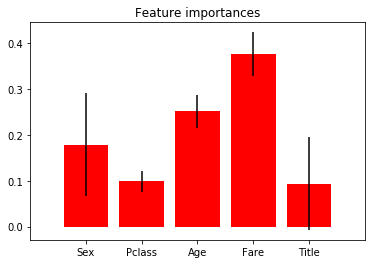

```
Performence: 0.817927170868
```

```python
features = ['Sex', 'Pclass', 'Age', 'Fare', 'Title']
model = RandomForest(n_estimators=10)
model.fit(data_train[features], target_train)
importances = model.feature_importances_
std = np.std([tree.feature_importances_ for tree in model.estimators_], axis=0)

for feature, imp, i in zip(features, importances, range(len(features))):
    print("  %d. %s -> %f" % (i+1, feature, imp))

# Plot the feature importances of the forest
plt.figure()
plt.title("Feature importances")
plt.bar(range(len(features)), importances, color="r", yerr=std, align="center")
plt.xticks(range(len(features)), np.array(features))
plt.xlim([-1, len(features)])
plt.show()

#Score
print('Performence:', model.score(data_test[features], target_test), '\n')
```

So we can see that our prediction improved meaning that our idea of create a Title column was good.  
Then we will create a dataframe that will display the prediction proposed by the random forest and the reality (survivor = 1, dead = 0) and then compare them in a last column called 'get_it'.

```python
print('==> predict: ')
prediction = model.predict(data_test[features])
reality = target_test
result = pd.DataFrame({'prediction': prediction,
                       'reality': reality})
result['get_it'] = 'non'
result.loc[result.prediction == result.reality, 'get_it'] = 'yes'

print(result.head(10))
print('  == get_it:')
print(result.get_it.value_counts())
#exit('\nstop here')
```

```
==> predict:
     prediction  reality get_it
709           1        0    non
439           1        1    yes
840           0        0    yes
720           0        1    non
39            0        0    yes
290           0        0    yes
300           0        0    yes
333           0        1    non
208           0        0    yes
136           1        0    non
  == get_it:
yes    292
non     65
Name: get_it, dtype: int64
```

**II. B - Decision Tree**

Now that we have seen the most important variables in the decision of passenger death, we can now make a decision tree including first sex which is a binary attribute making the decision tree more understandable.

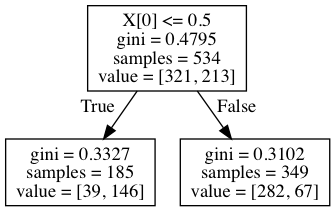

```python
# A nécessité d'un 'brew install graphviz' sur terminal
from sklearn.tree import DecisionTreeClassifier
from sklearn import tree
from io import StringIO
from IPython.display import Image
import pydotplus

#make classifier with our feature
features = ['Sex']
predictors = titanic_df[features]
targets = titanic_df.Survived
pred_train, pred_test, tar_train, tar_test = train_test_split(predictors, targets, test_size=.4)
classifier = DecisionTreeClassifier(min_samples_split=20, random_state=10)
classifier = classifier.fit(pred_train, tar_train)

#Draw
out = StringIO()
tree.export_graphviz(classifier, out_file=out)
graph=pydotplus.graph_from_dot_data(out.getvalue())
Image(graph.create_png())
```

Then the decision tree including sex and age where X[0] is Sex and X[1] is age.

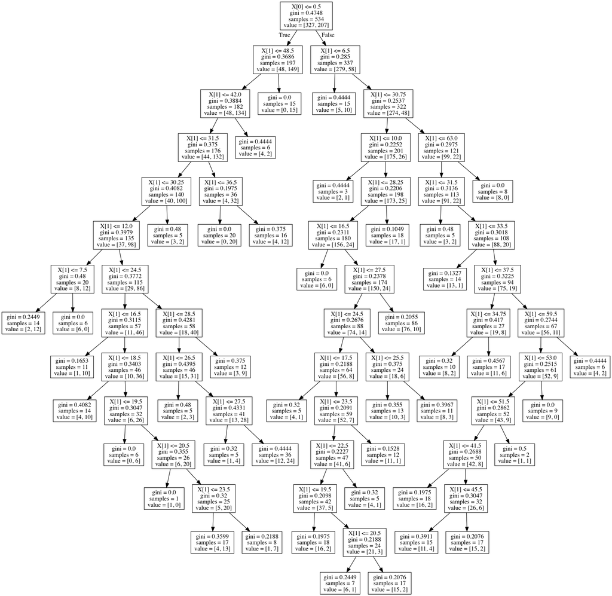

```python
#make classifier with our feature
features = ['Sex', 'Age']
predictors = titanic_df[features]
targets = titanic_df.Survived
pred_train, pred_test, tar_train, tar_test = train_test_split(predictors, targets, test_size=.4)
classifier = DecisionTreeClassifier(min_samples_split=20, random_state=10)
classifier = classifier.fit(pred_train, tar_train)

#Draw
out = StringIO()
tree.export_graphviz(classifier, out_file=out)
graph=pydotplus.graph_from_dot_data(out.getvalue())
Image(graph.create_png())
```

It is finished for this presentation of some machine learning algorithms around the **Titanic** data!